# Hands on : Using MaBoSS with pyMaBoSS

## 1. Introduction: Prostate Cancer Boolean model

This material has been adapted from Vincent Noël

The model used in this material was presented in Montagud, A., Béal, J., Tobalina, L., Traynard, P., Subramanian, V., Szalai, B., Alföldi, R., Puskás, L., Valencia, A., Barillot, E., Saez-Rodriguez, J., & Calzone, L. (2022). "Patient-specific Boolean models of signalling networks guide personalised treatments". *eLife*, **11**, e72626. https://doi.org/10.7554/eLife.72626

The model can be considered as a model of healthy prostate cells when no mutants (or fused genes) are present. We refer to this model as the wild type model.

[figure not shown]

This jupyter notebook was last edited 3 December 2025.

## 2. Material and methods

### 2.1 Installation

This notebook can be run on a recent personal computer with at least 16 Go of RAM and about 10 Go of available disk space. The *CoLoMoTo* environment [1] can be installed either as a *Docker* container or as individual *conda* packages.

#### 2.1.1 Installation of CoLoMoTo conda packages

One can rely on *conda* to create a software environment able to reproduce the notebook on *Linux* and *macOS* computers by typing the following commands in a terminal:

```
conda create -n WCS2025 -c colomoto -c potassco -c conda-forge pymaboss notebook seaborn numpy pandas matplotlib pip
# note: the environment should have been created in the VMs.

conda activate WCS2025
pip install pctk ipylab
```

To launch this notebook open in VS Code or type the command:

```
jupyter notebook
```

#### 2.1.2 Installation of the CoLoMoTo Docker container

Alternatively, *Docker* allows packaging a complete pre-installed software environment, so that applications can run consistently across different machines and operating systems. As such, it is well adapted to reproduce complex computational workflows, relying on numerous software. *Docker* and *Python* need to be pre-installed, go to your folder and then type in a terminal:

```
pip install -U colomoto-docker
colomoto-docker -V 2025-03-01 --bind .
```

Now we import MaBoSS:

```python
import glob, os, re
import maboss
```

## 3. Hands-on 1: Simulating the Prostate Cancer Boolean model

### 3.1 Loading the model

```python
MODEL_BND = "models/Montagud2022_Prostate_Cancer.bnd"
MODEL_CFG = "models/Montagud2022_Prostate_Cancer.cfg"
```

First, we need to load the model to create a Simulation. Here is pyMaBoSS' documentation regarding the loading a model : https://pymaboss.readthedocs.io/en/latest/api/load.html

Fill the next block to store the simulation in the variable model_prostate

```python
model_prostate = maboss.load(MODEL_BND, MODEL_CFG)
```

The Simulation object has several objects or methods that you can use. Here is the documentation : https://pymaboss.readthedocs.io/en/latest/api/simulation.html

You can also use python help() command to get the same information (without proper formatting unfortunately)

```python
help(model_prostate)
```

```
Help on Simulation in module maboss.simulation object:

class Simulation(builtins.object)
 |  Simulation(
 |      nt,
 |      parameters=OrderedDict(),
 |      command=None,
 |      mutations=[],
 |      mutationsTypes={},
 |      **kwargs
 |  )
 |  Class that handles MaBoSS simulations.
 |  .. py:attribute:: network
 |    A Network object, that will be translated in a bnd file
 |  .. py:attribute:: mutations
 |    A list of nodes for which mutation can be triggered by
 |    modifying the cfg file
 |  .. py:attribute:: palette
 |    A mapping of nodes to color for plotting the results of
 |    the simulation.
 |  .. py:attribute:: param
 |    A dictionary that contains global variables (keys starting with a '$'),
 |    and simulation parameters (keys not starting with a '$').
 |  Methods defined here:
 |  __init__(
 |      self,
 |      nt,
 |      parameters=OrderedDict(),
 |      command=None,
 |      mutations=[],
 |      mutationsTypes={},
 |      **kwargs
 |  )
 |      Initialize the Simulation object.
 |      :param nt: the network associated with the simulation.
 |      :type nt: :py:class:`Network`
 |      :param dict kwargs: parameters of the simulation
 |  check(self, command=None)
 |  continue_from_result(self, result)
 |      Set the initial state from as the last state from result.
```

[output cut: 31 more lines]

```
 |      only_final_state=False
 |  )
 |      Run the simulation with MaBoSS and return a Result object.
 |      :param command: specify a MaBoSS command, default to None for automatic selection
 |      :rtype: :py:class:`Result`
 |  set_workdir(self, path, overwrite=False)
 |  str_cfg(self)
 |  update_parameters(self, **kwargs)
 |      Add elements to ``self.param``.
 |  ----------------------------------------------------------------------
 |  Data descriptors defined here:
 |  __dict__
 |      dictionary for instance variables
 |  __weakref__
 |      list of weak references to the object
```

### 3.2 Run the default simulation

Now that the simulation is created, we can already simulate the default case, without changing any settings.

Here is the documentation of the function to run a simulation : https://pymaboss.readthedocs.io/en/latest/api/simulation.html#maboss.simulation.Simulation.run

Fill the next block to run the simulation and store the result in the res_prostate variable

```python
res_prostate = model_prostate.run()
```

The Result object has many options to access the results, or visualize them. Here is the documentation : https://pymaboss.readthedocs.io/en/latest/api/result.html

#### 3.2.1 Print results

Now that we simulated the model, we can visualize the results. The simplest kind of result that we often look is the states probability distribution of last time point. Fill the next block to visualize it :

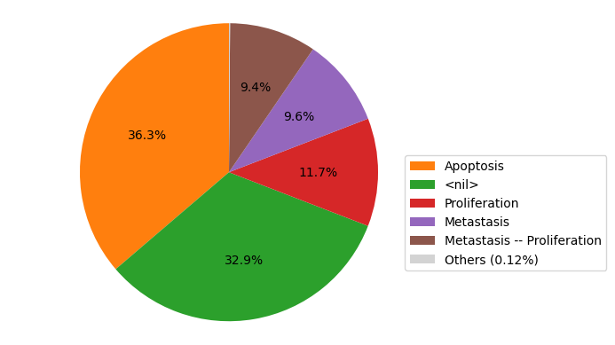

```python
res_prostate.plot_piechart()
```

#### 3.2.2 Printing the list of nodes

One important variable of the Simulation is the Network, which stores all of the information on the Boolean network. Here is the documentation related to the Network object : https://pymaboss.readthedocs.io/en/latest/api/network.html. It allows to modify initial states, or to set output nodes (which nodes will be part of the results), and can be accessed by using Simulation.Network, for example : model_prostate.network.

If we want to perform modifications on the model (changing output nodes, initial values, or simulating mutants), one important information is the list of the nodes of the model. You can print them with the following command :

```python
print(model_prostate.network.names)
```

```
['Acidosis', 'AKT', 'AMPK', 'AMP_ATP', 'Androgen', 'APAF1', 'Apoptosis', 'AR', 'AR_ERG', 'ATM', 'ATR', 'AXIN1', 'BAD', 'Bak', 'BAX', 'BCL2', 'Bcl_XL', 'beta_catenin', 'BIRC5', 'BMP2', 'BRCA1', 'BRCA2', 'Carcinogen', 'Caspase3', 'Caspase8', 'Caspase9', 'CDH2', 'cFLAR', 'CHK1_2', 'COX4I2', 'CyclinB', …
```

### 3.3 Simulating the Wild Type

The default simulation use all the possible combinations of input nodes, in order to show all the possible phenotypes. Now suppose we want to simulate the healthy condition for this model. It is defined in the paper as :

*These healthy cells mostly exhibit quiescence (neither proliferation nor apoptosis) in the absence of any input (Figure 3A)*

So in this case, we need to inactivate all the inputs. We provide here the list of inputs, created by listing all the inputs nodes in the interaction graph.

```python
input_nodes = ['EGF', 'FGF', 'Androgen', 'TGFb', 'Hypoxia', 'Nutrients', 'Carcinogen', 'fused_event', 'Acidosis', 'SPOP', 'TNFalpha']
```

Here is the documentation of the function to set new initial values : https://pymaboss.readthedocs.io/en/latest/api/network.html#maboss.network.Network.set_istate

Complete the next block to set the initial states of all the nodes to zero :

```python
model_prostate_zero = model_prostate.copy()
for node in input_nodes:
    model_prostate_zero.network.set_istate(node, [1, 0])
```

With all nodes initial values to zero, we can now simulate the model and print the trajectories of the node probabilities to reproduce Figure 3A of the article

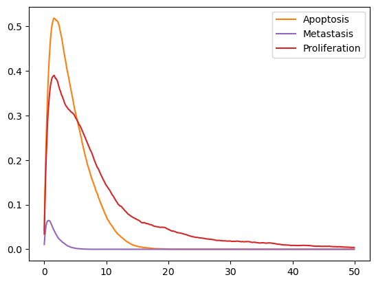

```python
res_prostate_zero = model_prostate_zero.run()
res_prostate_zero.plot_node_trajectory()
```

### 3.4 Simulating the growth conditions

Now we want to simulate a case where cells are proliferating. To do this, we need to activate the input nodes which will trigger this phenotype. It is defined in the paper as :

*When Nutrients and growth factors (EGF or FGF) are present, Proliferation is activated*

```python
prostate_growth = model_prostate_zero.copy()
```

Using the same function as previously, complete the next block to set new initial values :

```python
prostate_growth.network.set_istate('EGF', [0, 1])
prostate_growth.network.set_istate('Nutrients', [0, 1])
```

Then simulate the model, and plot the state probability distributions of the last time point to verify that we obtain a proliferative phenotype with a piechart and a node_trajectory.

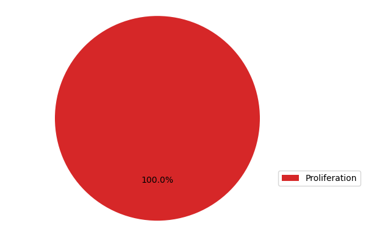

```python
res_prostate_growth = prostate_growth.run()
res_prostate_growth.plot_piechart()
```

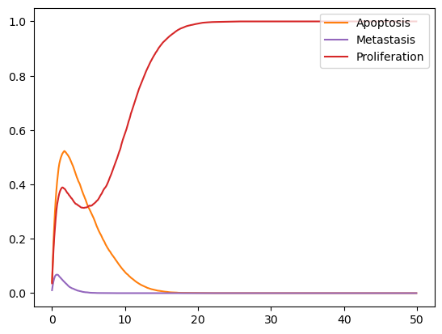

```python
res_prostate_growth.plot_node_trajectory()
```

## 4. Hands-on 2: Simulating mutants

### 4.1 Simulating MYC_MAX mutant on proliferative phenotype

Now we want to reproduce one result on this model: MYC_MAX inhibition will inhibit the proliferative phenotype (Appendix 1—figure 34)

```python
mutant_prostate_growth = prostate_growth.copy()
```

To simulate the inhibition of a node, we need to use the mutate function : https://pymaboss.readthedocs.io/en/latest/api/simulation.html#maboss.simulation.Simulation.mutate

Fill the next block to modify the simulation mutant_prostate_growth to simulate an inhibition on the MYC_MAX node :

```python
mutant_prostate_growth.mutate("MYC_MAX", "OFF")
```

Then run the simulation, and plot the state probability distribution of the final state :

```python
res_mutant_prostate_growth = mutant_prostate_growth.run()
```

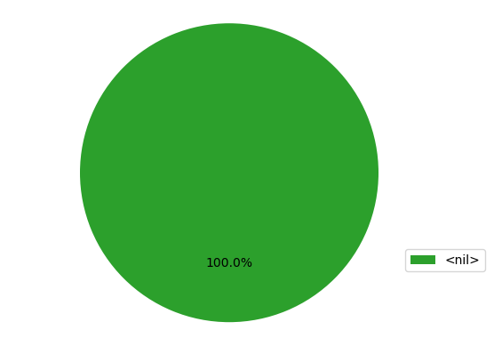

```python
res_mutant_prostate_growth.plot_piechart()
```

### 4.2 Stretch goal: Checking multiple single node mutants

Now we may be interested in testing multiple mutants, to try to find other interesting mutations which would reduce or block proliferation. pyMaBoSS propose methods to help with this : https://pymaboss.readthedocs.io/en/latest/api/sensitivity_api.html

Hint: look at

```
help(simulate_single_mutants)
help(filter_sensitivity)
```

```python
from maboss.pipelines import simulate_single_mutants, filter_sensitivity
candidates_nodes = ["AKT", "AR", "EGFR", "ERK", "MYC_MAX", "ROS"]
simulations = simulate_single_mutants(prostate_growth, candidates_nodes , "OFF")
print(simulations)
```

```
{('AKT', 'OFF'): <maboss.result.Result object at 0x74d81dfa0cd0>, ('AR', 'OFF'): <maboss.result.Result object at 0x74d81dfa0e10>, ('EGFR', 'OFF'): <maboss.result.Result object at 0x74d81dfa0f50>, ('ERK', 'OFF'): <maboss.result.Result object at 0x74d81dfa1090>, ('MYC_MAX', 'OFF'): <maboss.result.Resu…
```

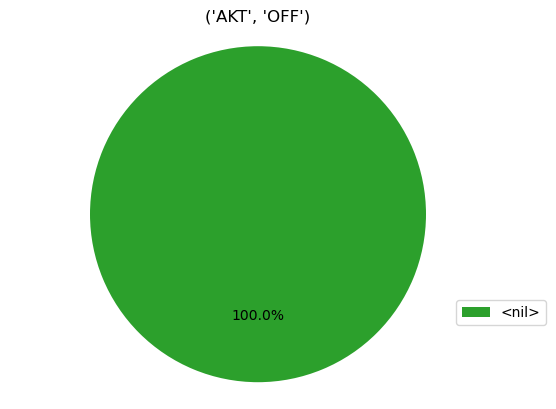

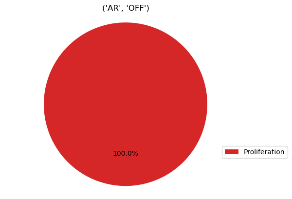

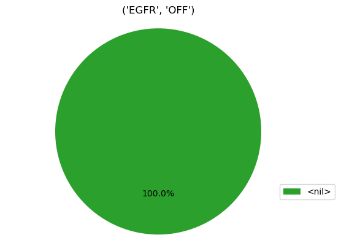

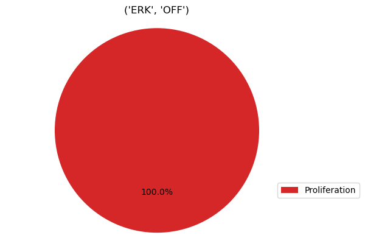

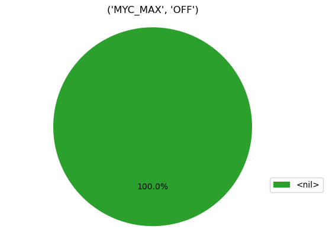

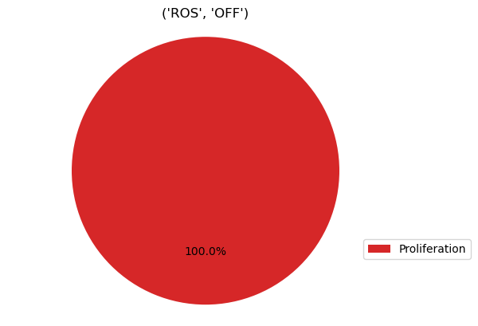

```python
import matplotlib.pyplot as plt
for simulation, result in simulations.items():
    result.plot_piechart()
    plt.title(simulation)
```

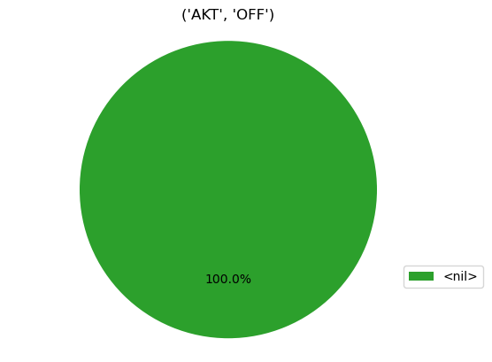

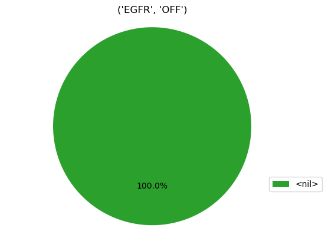

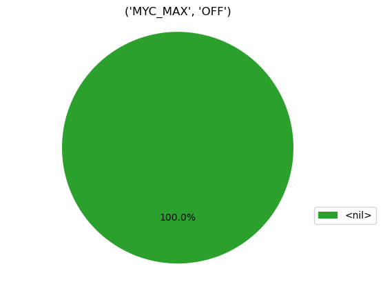

```python
res_filtered = filter_sensitivity(simulations, state='Proliferation', maximum=0)
for simulation, result in res_filtered.items():
    result.plot_piechart()
    plt.title(simulation)
```

## 5. Hands-on 3: Simulating drug inhibition in prostate cell-line-specific Boolean models

### 5.1 Simulating prostate cell-line-specific Boolean models

In this article, Montagud et al. generated multiple personalized versions of the model, corresponding to patients or cell lines. Here, we're going to work with a subset of them for simplicity. In the next block, we build a dictionnary of models, with an identifier as key, and the Simulation object as value

```python
patients_models = {}
bnd_files = sorted(glob.glob("models/cell_lines/Montagud2022_Prostate_Cancer_mut_RNA_*.bnd"))
for bnd in bnd_files:
    cfg = os.path.splitext(bnd)[0] + '.cfg'
    m = re.search(r"_mut_RNA_(\d+)", bnd)
    if m:
        idx = m.group(1)
    else:
        idx = os.path.splitext(os.path.basename(bnd))[0]
    patients_models[f'model_{idx}'] = maboss.load(bnd, cfg)
patients_models
```

```
{'model_0': <maboss.simulation.Simulation at 0x74d826680410>,
 'model_1': <maboss.simulation.Simulation at 0x74d826917c50>,
 'model_2': <maboss.simulation.Simulation at 0x74d81da8e430>,
 'model_3': <maboss.simulation.Simulation at 0x74d826768670>,
 'model_4': <maboss.simulation.Simulation at 0x74d826a11300>,
 'model_5': <maboss.simulation.Simulation at 0x74d8269cbd10>,
 'model_6': <maboss.simulation.Simulation at 0x74d8269cbdd0>,
 'model_7': <maboss.simulation.Simulation at 0x74d8cac9e4c0>,
 'model_8': <maboss.simulation.Simulation at 0x74d8ca3b2990>}
```

Now in the next block, simulate all of these models, and build a panda DataFrame with the state probability distribution of the last time point, for all the models

```python
import pandas
last_states = pandas.DataFrame()
for name, model in patients_models.items():
    res = model.run()
    last_state = res.get_last_states_probtraj()

    last_state.index = [name]
    last_states = pandas.concat([last_states, last_state])
```

```python
last_states
```

|  | <nil> | Angiogenesis -- Glycolysis -- Invasion -- Proliferation | Angiogenesis -- Invasion -- Proliferation | Apoptosis | Apoptosis -- DNA_Repair | Apoptosis -- DNA_Repair -- Glycolysis -- Invasion -- Proliferation | Apoptosis -- DNA_Repair -- Invasion | Apoptosis -- Glycolysis -- Invasion | Apoptosis -- Glycolysis -- Invasion -- Proliferation | Apoptosis -- Invasion | Apoptosis -- Invasion -- Proliferation | Apoptosis -- Proliferation | DNA_Repair -- Glycolysis | DNA_Repair -- Glycolysis -- Invasion -- Proliferation | DNA_Repair -- Glycolysis -- Invasion -- Quiescence | DNA_Repair -- Glycolysis -- Proliferation | DNA_Repair -- Glycolysis -- Quiescence | DNA_Repair -- Invasion -- Proliferation | DNA_Repair -- Invasion -- Quiescence | DNA_Repair -- Proliferation | DNA_Repair -- Quiescence | Glycolysis | Glycolysis -- Invasion | Glycolysis -- Invasion -- Migration -- Proliferation | Glycolysis -- Invasion -- Migration -- Quiescence | Glycolysis -- Invasion -- Proliferation | Glycolysis -- Invasion -- Proliferation -- Quiescence | Glycolysis -- Invasion -- Quiescence | Glycolysis -- Proliferation | … |
| --- | --- | --- | --- | --- | --- | --- | --- | --- | --- | --- | --- | --- | --- | --- | --- | --- | --- | --- | --- | --- | --- | --- | --- | --- | --- | --- | --- | --- | --- | --- |
| model_0 | 0.000746 | 0.0002 | 0.0002 | 0.000400 | 0.0004 | 0.0002 | 0.000200 | 0.000200 | 0.0010 | 0.000200 | 0.0004 | 0.0004 | 0.000084 | 0.0088 | 0.011600 | 0.000600 | 0.005116 | 0.007600 | 0.011800 | 0.001200 | 0.009200 | 0.000600 | 0.001200 | 0.000200 | 0.000200 | 0.202190 | 0.000600 | 0.170373 | 0.027410 | … |
| model_1 | NaN | 0.0002 | 0.0002 | NaN | NaN | NaN | NaN | NaN | NaN | NaN | NaN | NaN | NaN | NaN | NaN | NaN | NaN | NaN | NaN | NaN | NaN | NaN | 0.000600 | 0.001805 | 0.001600 | 0.286630 | 0.001965 | 0.175285 | NaN | … |
| model_2 | 0.001358 | NaN | NaN | 0.023200 | 0.0014 | NaN | NaN | 0.000200 | NaN | 0.001400 | NaN | NaN | 0.000200 | 0.0020 | 0.006354 | 0.001000 | 0.044698 | 0.003200 | 0.009200 | 0.000600 | 0.054252 | 0.000108 | 0.000498 | NaN | 0.000614 | 0.014600 | 0.000200 | 0.038139 | 0.037892 | … |
| model_3 | NaN | NaN | NaN | NaN | NaN | NaN | NaN | NaN | NaN | NaN | NaN | NaN | NaN | 0.0302 | 0.068000 | NaN | NaN | 0.023414 | 0.054600 | NaN | NaN | NaN | NaN | 0.005400 | 0.002200 | 0.189200 | 0.000600 | 0.199400 | NaN | … |
| model_4 | 0.000200 | NaN | NaN | 0.016107 | 0.0002 | 0.0002 | 0.000960 | 0.032972 | 0.0014 | 0.042276 | 0.0024 | NaN | NaN | 0.0028 | 0.016000 | NaN | 0.024600 | 0.002800 | 0.017340 | NaN | 0.030005 | 0.000600 | 0.002028 | 0.004400 | 0.017288 | 0.021354 | 0.001646 | 0.125763 | 0.020600 | … |
| model_5 | 0.000823 | NaN | NaN | 0.037170 | 0.0038 | NaN | 0.007560 | 0.007906 | 0.0002 | 0.087294 | 0.0002 | NaN | 0.000200 | NaN | 0.001400 | 0.000400 | 0.002000 | 0.000200 | 0.009119 | 0.000600 | 0.035000 | 0.001200 | 0.000200 | 0.063388 | 0.064773 | 0.000944 | 0.000368 | 0.000957 | 0.013256 | … |
| model_6 | 0.003060 | 0.0010 | 0.0004 | 0.017200 | 0.0026 | NaN | 0.004118 | 0.005870 | 0.0016 | 0.018282 | 0.0046 | 0.0066 | 0.000400 | 0.0028 | 0.011400 | 0.010004 | 0.019216 | 0.006362 | 0.021800 | 0.013519 | 0.045400 | 0.002656 | 0.000836 | 0.003600 | 0.007356 | 0.026918 | 0.000600 | 0.071804 | 0.086732 | … |
| model_7 | 0.000948 | NaN | NaN | 0.037800 | 0.0012 | NaN | 0.001200 | 0.077600 | NaN | 0.229600 | 0.0002 | NaN | NaN | 0.0002 | NaN | NaN | NaN | 0.000072 | NaN | NaN | 0.015800 | 0.000598 | 0.000175 | 0.096875 | 0.119833 | 0.002325 | 0.000400 | 0.010167 | 0.012942 | … |
| model_8 | 0.000772 | NaN | NaN | 0.006248 | 0.0056 | NaN | 0.010008 | 0.002800 | 0.0002 | 0.011400 | 0.0010 | 0.0004 | NaN | 0.0008 | 0.010373 | 0.000400 | 0.017651 | 0.001400 | 0.039461 | 0.001000 | 0.080350 | 0.000200 | 0.000400 | NaN | 0.004600 | 0.007000 | NaN | 0.095481 | 0.004800 | … |

We can observe a lot of variations in the obtained phenotypes.

Now let's go back to our initial problem: the inhibition of the proliferative phenotype. Fill the next block by building a similar array, but this time simulating the proliferative phenotype with a MYC_MAX inhibition.

```python
import pandas
last_states = pandas.DataFrame()
for name, model in patients_models.items():
    t_model = model.copy()
    t_model.network.set_istate('EGF', [0, 1])
    t_model.network.set_istate('Nutrients', [0, 1])
    t_model.mutate('MYC_MAX', 'OFF')
    res = t_model.run()
    last_state = res.get_last_states_probtraj()

    last_state.index = [name]
    last_states = pandas.concat([last_states, last_state])
```

```python
last_states
```

|  | <nil> | Apoptosis | Apoptosis -- DNA_Repair | Apoptosis -- DNA_Repair -- Glycolysis | Apoptosis -- DNA_Repair -- Glycolysis -- Invasion -- Proliferation | Apoptosis -- DNA_Repair -- Glycolysis -- Invasion -- Quiescence | Apoptosis -- DNA_Repair -- Glycolysis -- Quiescence | Apoptosis -- DNA_Repair -- Invasion | Apoptosis -- Glycolysis | Apoptosis -- Glycolysis -- Invasion | Apoptosis -- Invasion | Apoptosis -- Proliferation | DNA_Repair | DNA_Repair -- Glycolysis -- Invasion -- Proliferation | DNA_Repair -- Glycolysis -- Invasion -- Quiescence | DNA_Repair -- Glycolysis -- Quiescence | DNA_Repair -- Invasion | DNA_Repair -- Invasion -- Proliferation | DNA_Repair -- Invasion -- Proliferation -- Quiescence | DNA_Repair -- Invasion -- Quiescence | DNA_Repair -- Proliferation | DNA_Repair -- Quiescence | Glycolysis | Glycolysis -- Invasion | Glycolysis -- Invasion -- Migration -- Quiescence | Glycolysis -- Invasion -- Proliferation | Glycolysis -- Invasion -- Proliferation -- Quiescence | Glycolysis -- Invasion -- Quiescence | Glycolysis -- Proliferation | … |
| --- | --- | --- | --- | --- | --- | --- | --- | --- | --- | --- | --- | --- | --- | --- | --- | --- | --- | --- | --- | --- | --- | --- | --- | --- | --- | --- | --- | --- | --- | --- |
| model_0 | 0.001600 | 0.000800 | 0.000800 | 0.000400 | 0.0004 | 0.000200 | 0.000076 | 0.000400 | 0.000600 | 0.000400 | 0.000400 | 0.0002 | 0.000200 | 0.0048 | 0.024943 | 0.008781 | 0.0002 | 0.0098 | 0.0002 | 0.0128 | 0.0022 | 0.011000 | 0.000400 | 0.001200 | 0.001200 | 0.070713 | 0.001016 | 0.332133 | 0.001800 | … |
| model_1 | NaN | NaN | NaN | NaN | NaN | NaN | NaN | NaN | NaN | NaN | NaN | NaN | NaN | NaN | NaN | NaN | NaN | NaN | NaN | NaN | NaN | NaN | NaN | 0.000400 | 0.002800 | 0.118018 | 0.000870 | 0.331066 | NaN | … |
| model_2 | 0.000107 | 0.015000 | 0.001400 | 0.000800 | NaN | NaN | NaN | NaN | 0.017265 | 0.001038 | 0.001000 | NaN | NaN | 0.0054 | 0.012200 | 0.089600 | NaN | 0.0024 | NaN | 0.0006 | NaN | 0.007200 | 0.001230 | 0.000944 | 0.002600 | 0.023931 | 0.001199 | 0.078831 | 0.004000 | … |
| model_3 | NaN | NaN | NaN | NaN | NaN | NaN | NaN | NaN | NaN | NaN | NaN | NaN | NaN | 0.0502 | 0.119800 | NaN | NaN | NaN | NaN | NaN | NaN | NaN | NaN | NaN | 0.008200 | 0.397107 | 0.000200 | 0.409600 | NaN | … |
| model_4 | NaN | 0.003018 | NaN | 0.000400 | 0.0002 | 0.000043 | NaN | NaN | 0.020782 | 0.064200 | 0.011400 | NaN | NaN | 0.0060 | 0.029436 | 0.052893 | NaN | 0.0004 | 0.0002 | 0.0006 | NaN | 0.002800 | 0.001800 | 0.002865 | 0.040556 | 0.042400 | 0.000432 | 0.247278 | NaN | … |
| model_5 | 0.001000 | 0.036600 | 0.004775 | 0.001200 | 0.0002 | 0.000590 | NaN | 0.004439 | 0.009200 | 0.011133 | 0.078961 | NaN | 0.000400 | NaN | 0.001802 | 0.005349 | NaN | 0.0002 | 0.0002 | 0.0098 | NaN | 0.026000 | 0.001400 | NaN | 0.138904 | 0.000800 | 0.000800 | 0.003363 | 0.000200 | … |
| model_6 | 0.000570 | 0.013444 | 0.003600 | 0.002058 | 0.0004 | 0.000063 | 0.000200 | 0.004000 | 0.012356 | 0.011283 | 0.011000 | 0.0030 | 0.000200 | 0.0074 | 0.025728 | 0.047623 | NaN | 0.0004 | NaN | 0.0078 | 0.0016 | 0.026846 | 0.003918 | 0.003549 | 0.019506 | 0.045254 | 0.000600 | 0.135210 | 0.096320 | … |
| model_7 | NaN | 0.026600 | NaN | NaN | NaN | NaN | NaN | NaN | 0.026800 | 0.152200 | 0.153400 | NaN | NaN | NaN | NaN | NaN | NaN | NaN | NaN | NaN | NaN | 0.017200 | NaN | NaN | 0.293800 | NaN | NaN | NaN | NaN | … |
| model_8 | 0.000712 | 0.004600 | 0.006384 | 0.002271 | NaN | 0.000733 | 0.000529 | 0.007200 | 0.002200 | 0.004360 | 0.005400 | NaN | 0.000308 | 0.0008 | 0.020311 | 0.031800 | 0.0004 | 0.0004 | NaN | 0.0296 | 0.0006 | 0.062892 | 0.000182 | 0.000200 | 0.007800 | 0.005600 | 0.000800 | 0.177635 | 0.001837 | … |

Now filter this dataframe to only show the personalized models which show less than 10% of Proliferation

```python
last_states[last_states['Proliferation'] < 0.1]
```

|  | <nil> | Apoptosis | Apoptosis -- DNA_Repair | Apoptosis -- DNA_Repair -- Glycolysis | Apoptosis -- DNA_Repair -- Glycolysis -- Invasion -- Proliferation | Apoptosis -- DNA_Repair -- Glycolysis -- Invasion -- Quiescence | Apoptosis -- DNA_Repair -- Glycolysis -- Quiescence | Apoptosis -- DNA_Repair -- Invasion | Apoptosis -- Glycolysis | Apoptosis -- Glycolysis -- Invasion | Apoptosis -- Invasion | Apoptosis -- Proliferation | DNA_Repair | DNA_Repair -- Glycolysis -- Invasion -- Proliferation | DNA_Repair -- Glycolysis -- Invasion -- Quiescence | DNA_Repair -- Glycolysis -- Quiescence | DNA_Repair -- Invasion | DNA_Repair -- Invasion -- Proliferation | DNA_Repair -- Invasion -- Proliferation -- Quiescence | DNA_Repair -- Invasion -- Quiescence | DNA_Repair -- Proliferation | DNA_Repair -- Quiescence | Glycolysis | Glycolysis -- Invasion | Glycolysis -- Invasion -- Migration -- Quiescence | Glycolysis -- Invasion -- Proliferation | Glycolysis -- Invasion -- Proliferation -- Quiescence | Glycolysis -- Invasion -- Quiescence | Glycolysis -- Proliferation | … |
| --- | --- | --- | --- | --- | --- | --- | --- | --- | --- | --- | --- | --- | --- | --- | --- | --- | --- | --- | --- | --- | --- | --- | --- | --- | --- | --- | --- | --- | --- | --- |
| model_0 | 0.001600 | 0.000800 | 0.000800 | 0.000400 | 0.0004 | 0.000200 | 0.000076 | 0.0004 | 0.000600 | 0.000400 | 0.0004 | 0.0002 | 0.000200 | 0.0048 | 0.024943 | 0.008781 | 0.0002 | 0.0098 | 0.0002 | 0.0128 | 0.0022 | 0.011000 | 0.000400 | 0.001200 | 0.001200 | 0.070713 | 0.001016 | 0.332133 | 0.001800 | … |
| model_2 | 0.000107 | 0.015000 | 0.001400 | 0.000800 | NaN | NaN | NaN | NaN | 0.017265 | 0.001038 | 0.0010 | NaN | NaN | 0.0054 | 0.012200 | 0.089600 | NaN | 0.0024 | NaN | 0.0006 | NaN | 0.007200 | 0.001230 | 0.000944 | 0.002600 | 0.023931 | 0.001199 | 0.078831 | 0.004000 | … |
| model_6 | 0.000570 | 0.013444 | 0.003600 | 0.002058 | 0.0004 | 0.000063 | 0.000200 | 0.0040 | 0.012356 | 0.011283 | 0.0110 | 0.0030 | 0.000200 | 0.0074 | 0.025728 | 0.047623 | NaN | 0.0004 | NaN | 0.0078 | 0.0016 | 0.026846 | 0.003918 | 0.003549 | 0.019506 | 0.045254 | 0.000600 | 0.135210 | 0.096320 | … |
| model_8 | 0.000712 | 0.004600 | 0.006384 | 0.002271 | NaN | 0.000733 | 0.000529 | 0.0072 | 0.002200 | 0.004360 | 0.0054 | NaN | 0.000308 | 0.0008 | 0.020311 | 0.031800 | 0.0004 | 0.0004 | NaN | 0.0296 | 0.0006 | 0.062892 | 0.000182 | 0.000200 | 0.007800 | 0.005600 | 0.000800 | 0.177635 | 0.001837 | … |

### 5.2 Simulating drug inhibition in prostate cell-line-specific Boolean models

- Go to `PROFILE_v2\Gradient inhibition of nodes` folder
- Run `run_double_2025.sh`
  - Runs the LNCaP WT
  - Runs inhibitions of HSPs and PI3K
    - 0%, 20%, 40%, 60%, 80%, 100%
- Install R in the conda environment, if not already installed

```
conda install conda-forge::r-base
conda install conda-forge::r-essentials
```

- Run `data_gathering_double_2025.R`
  - Builds dataframes of all the simulations
- Run `data_analysis_2025.R`
  - Wrangles data and makes figures

```python
%%sh
cd ./PROFILE_v2/Gradient\ inhibition\ of\ nodes
./run_double_2025.sh
```

```
Creating the WT_sims folder
Running the WT model
Arguments:

Namespace(model='LNCAP_mutRNA_EGF', drugs='HSPs, PI3K', drug_conc='0, 0.2, 0.4, 0.6, 0.8, 1')


Model: LNCAP_mutRNA_EGF
Nodes to be inhibited: HSPs, PI3K
Inhibited nodes' levels: 0.0, 0.2, 0.4, 0.6, 0.8, 1.0
Modifying BND file: adding inhibitor nodes and inhibitions
Modifying CFG file: istate formatting
creating HSPs PI3K combinations
1/36 mutant: LNCAP_mutRNA_EGF_HSPs_0_0_PI3K_0_0
2/36 mutant: LNCAP_mutRNA_EGF_HSPs_0_0_PI3K_0_2
3/36 mutant: LNCAP_mutRNA_EGF_HSPs_0_0_PI3K_0_4
4/36 mutant: LNCAP_mutRNA_EGF_HSPs_0_0_PI3K_0_6
5/36 mutant: LNCAP_mutRNA_EGF_HSPs_0_0_PI3K_0_8
6/36 mutant: LNCAP_mutRNA_EGF_HSPs_0_0_PI3K_1_0
7/36 mutant: LNCAP_mutRNA_EGF_HSPs_0_2_PI3K_0_0
8/36 mutant: LNCAP_mutRNA_EGF_HSPs_0_2_PI3K_0_2
9/36 mutant: LNCAP_mutRNA_EGF_HSPs_0_2_PI3K_0_4
10/36 mutant: LNCAP_mutRNA_EGF_HSPs_0_2_PI3K_0_6
11/36 mutant: LNCAP_mutRNA_EGF_HSPs_0_2_PI3K_0_8
12/36 mutant: LNCAP_mutRNA_EGF_HSPs_0_2_PI3K_1_0
13/36 mutant: LNCAP_mutRNA_EGF_HSPs_0_4_PI3K_0_0
14/36 mutant: LNCAP_mutRNA_EGF_HSPs_0_4_PI3K_0_2
15/36 mutant: LNCAP_mutRNA_EGF_HSPs_0_4_PI3K_0_4
16/36 mutant: LNCAP_mutRNA_EGF_HSPs_0_4_PI3K_0_6
17/36 mutant: LNCAP_mutRNA_EGF_HSPs_0_4_PI3K_0_8
18/36 mutant: LNCAP_mutRNA_EGF_HSPs_0_4_PI3K_1_0
19/36 mutant: LNCAP_mutRNA_EGF_HSPs_0_6_PI3K_0_0
20/36 mutant: LNCAP_mutRNA_EGF_HSPs_0_6_PI3K_0_2
21/36 mutant: LNCAP_mutRNA_EGF_HSPs_0_6_PI3K_0_4
22/36 mutant: LNCAP_mutRNA_EGF_HSPs_0_6_PI3K_0_6
23/36 mutant: LNCAP_mutRNA_EGF_HSPs_0_6_PI3K_0_8
24/36 mutant: LNCAP_mutRNA_EGF_HSPs_0_6_PI3K_1_0
25/36 mutant: LNCAP_mutRNA_EGF_HSPs_0_8_PI3K_0_0
26/36 mutant: LNCAP_mutRNA_EGF_HSPs_0_8_PI3K_0_2
27/36 mutant: LNCAP_mutRNA_EGF_HSPs_0_8_PI3K_0_4
28/36 mutant: LNCAP_mutRNA_EGF_HSPs_0_8_PI3K_0_6
29/36 mutant: LNCAP_mutRNA_EGF_HSPs_0_8_PI3K_0_8
30/36 mutant: LNCAP_mutRNA_EGF_HSPs_0_8_PI3K_1_0
31/36 mutant: LNCAP_mutRNA_EGF_HSPs_1_0_PI3K_0_0
32/36 mutant: LNCAP_mutRNA_EGF_HSPs_1_0_PI3K_0_2
33/36 mutant: LNCAP_mutRNA_EGF_HSPs_1_0_PI3K_0_4
34/36 mutant: LNCAP_mutRNA_EGF_HSPs_1_0_PI3K_0_6
35/36 mutant: LNCAP_mutRNA_EGF_HSPs_1_0_PI3K_0_8
36/36 mutant: LNCAP_mutRNA_EGF_HSPs_1_0_PI3K_1_0
```

```python
# %load_ext rpy2.ipython
```

```python
# %%R -i df -w 5 -h 5 --units in -r 200
# install.packages("pacman", repos='http://cran.us.r-project.org', quiet=TRUE)
```

```python
%%sh
cd ./PROFILE_v2/Gradient\ inhibition\ of\ nodes
Rscript ./data_gathering_double_2025.R
```

[output not shown]

[output cut: 36 more lines]

```
There were 50 or more warnings (use warnings() to see the first 50)
```

```python
%%sh
cd ./PROFILE_v2/Gradient\ inhibition\ of\ nodes
Rscript ./data_analysis_2025.R
```

```
[1] "HSPs PI3K"
```

### 5.3 Stretch goal: Simulate another pair of drugs of your choosing.

Hint: Look at `run_double.sh`

## 6. Multiscale simulations

### 6.1 Hands-on 4: Multiscale simulation of prostate and drugs

- Git clone PhysiBoSS and PhysiCell ToolKit (PCTK), if not already installed

```
git clone https://github.com/PhysiBoSS/PhysiBoSS.git
git clone https://github.com/PhysiBoSS/pctk.git
```

- Go to `PhysiBoSS` folder
- Compile the project

```
make list-projects
make prostate; make
```

- Run the wild type simulation, without drugs

```
./prostate ./config/PhysiCell_settings_LNCaP.xml > out_nodrug.txt
# results in ./output_nodrug
pctk ./output_nodrug plot-time-course --figout fig_nodrug.png --csvout out_nodrug.csv
```

- Run the simulation with Luminespib using `PhysiCell_settings_LNCaP_Luminespib_2.xml`
- Run the simulation with Pictilisib using `PhysiCell_settings_LNCaP_Pictilisib_2.xml`
- Run the simulation with both drugs using `PhysiCell_settings_LNCaP_Luminespib_Pictilisib_2.xml`

```python
%%sh
cd ./PhysiBoSS/

./prostate ./config/PhysiCell_settings_LNCaP.xml > out_nodrug.txt
pctk ./output_nodrug plot-time-course --figout fig_out_nodrug.png --csvout out_nodrug.csv

./prostate ./config/PhysiCell_settings_LNCaP_Luminespib_2.xml > out_lumi.txt
pctk ./output_lumi plot-time-course --figout fig_out_lumi.png --csvout out_lumi.csv

./prostate ./config/PhysiCell_settings_LNCaP_Pictilisib_2.xml > out_picti.txt
pctk ./output_picti plot-time-course --figout fig_out_picti.png --csvout out_picti.csv

./prostate ./config/PhysiCell_settings_LNCaP_Luminespib_Pictilisib_2.xml > out_lumi_picti.txt
pctk ./output_lumi_picti plot-time-course --figout fig_out_lumi_picti.png --csvout out_lumi_picti.csv
```

```
sh: 3: ./prostate: not found
```

```
{0: 'Ki67_positive_premitotic', 1: 'Ki67_positive_postmitotic', 2: 'Ki67_positive', 3: 'Ki67_negative', 4: 'G0G1_phase', 5: 'G0_phase', 6: 'G1_phase', 7: 'G1a_phase', 8: 'G1b_phase', 9: 'G1c_phase', 10: 'S_phase', 11: 'G2M_phase', 12: 'G2_phase', 13: 'M_phase', 14: 'live', 100: 'apoptotic', 101: 'ne…
Reading cell_output files from 7 input files from ./output_nodrug
	Processing time step: 0
	Processing time step: 240
	Processing time step: 480
	Processing time step: 720
	Processing time step: 960
	Processing time step: 1200
	Processing time step: 1440
Finish processing files
Creating figure
Saving fig as fig_out_nodrug.png
Saving csv as out_nodrug.csv
```

```
sh: 6: ./prostate: not found
```

```
{0: 'Ki67_positive_premitotic', 1: 'Ki67_positive_postmitotic', 2: 'Ki67_positive', 3: 'Ki67_negative', 4: 'G0G1_phase', 5: 'G0_phase', 6: 'G1_phase', 7: 'G1a_phase', 8: 'G1b_phase', 9: 'G1c_phase', 10: 'S_phase', 11: 'G2M_phase', 12: 'G2_phase', 13: 'M_phase', 14: 'live', 100: 'apoptotic', 101: 'ne…
Reading cell_output files from 7 input files from ./output_lumi
	Processing time step: 0
	Processing time step: 240
	Processing time step: 480
	Processing time step: 720
	Processing time step: 960
	Processing time step: 1200
	Processing time step: 1440
Finish processing files
Creating figure
Saving fig as fig_out_lumi.png
Saving csv as out_lumi.csv
```

```
sh: 9: ./prostate: not found
```

```
{0: 'Ki67_positive_premitotic', 1: 'Ki67_positive_postmitotic', 2: 'Ki67_positive', 3: 'Ki67_negative', 4: 'G0G1_phase', 5: 'G0_phase', 6: 'G1_phase', 7: 'G1a_phase', 8: 'G1b_phase', 9: 'G1c_phase', 10: 'S_phase', 11: 'G2M_phase', 12: 'G2_phase', 13: 'M_phase', 14: 'live', 100: 'apoptotic', 101: 'ne…
Reading cell_output files from 7 input files from ./output_picti
	Processing time step: 0
	Processing time step: 240
	Processing time step: 480
	Processing time step: 720
	Processing time step: 960
	Processing time step: 1200
	Processing time step: 1440
Finish processing files
Creating figure
Saving fig as fig_out_picti.png
Saving csv as out_picti.csv
```

```
sh: 12: ./prostate: not found
```

[output not shown]

### 6.2 Stretch goal: Multiscale simulations of the effect of TNF treatments on cancer cells

```python
%%sh
cd ./PhysiBoSS/
# make reset; make clean
# make physiboss-tnf-model; make

./spheroid_TNF_model ./config/PhysiCell_settings_3D_WCS2025.xml > out_tnf0.txt
pctk ./output_tnf0 plot-time-course --figout fig_out_tnf0.png --csvout out_tnf0.csv

./spheroid_TNF_model ./config/PhysiCell_settings_3D_WCS2025_150.xml > out_tnf150.txt
pctk ./output_tnf150 plot-time-course --figout fig_out_tnf150.png --csvout out_tnf150.csv

./spheroid_TNF_model ./config/PhysiCell_settings_3D_WCS2025_600.xml > out_tnf600.txt
pctk ./output_tnf600 plot-time-course --figout fig_out_tnf600.png --csvout out_tnf600.csv

./spheroid_TNF_model ./config/PhysiCell_settings_3D_WCS2025_1000.xml > out_tnf1000.txt
pctk ./output_tnf1000 plot-time-course --figout fig_out_tnf1000.png --csvout out_tnf1000.csv
```

```
sh: 5: ./spheroid_TNF_model: not found
```

[output not shown]

```
sh: 8: ./spheroid_TNF_model: not found
```

[output not shown]

```
sh: 11: ./spheroid_TNF_model: not found
```

[output not shown]

```
sh: 14: ./spheroid_TNF_model: not found
```

[output not shown]